# Analysis of American Flights in 2020 slides

## Analysis of American Flights in 2020

- Introduction
- Gathering data
- Assessing data
- Cleaning data
- visualization

### Introduction

In this project i will analyse American flights during the year 2020. The aim is to answer these questions :

#### What percentage of flights has been cancelled?

#### Which Airline has had the most flight?

#### How many primary airports?

#### Number of Airlines?

#### Which airport has the most departing flights? least departing flights?

#### What Percentage of all flights depart from or arrive at Atlanta International Airport?

#### Number of Flights diverted?

#### Relationship between states based on Arrival and Departure.

#### Relationship between states based on Arrival and Departure with travel time.

Data was provided by BUREAU OF TRANSPORTATION STATISTICS, U.S. Department of Transportation. https://www.transtats.bts.gov/Fields.asp?Table_ID=236 To get started, let's import our libraries.

```python
flights_df.head()
```

|  | YEAR | MONTH | DAY_OF_MONTH | DAY_OF_WEEK | OP_UNIQUE_CARRIER | TAIL_NUM | OP_CARRIER_FL_NUM | ORIGIN_AIRPORT_ID | ORIGIN_AIRPORT_SEQ_ID | ORIGIN_CITY_MARKET_ID | ... | DIVERTED | CRS_ELAPSED_TIME | AIR_TIME | DISTANCE | CARRIER_DELAY | WEATHER_DELAY | NAS_DELAY | SECURITY_DELAY | LATE_AIRCRAFT_DELAY | Unnamed: 36 |
| --- | --- | --- | --- | --- | --- | --- | --- | --- | --- | --- | --- | --- | --- | --- | --- | --- | --- | --- | --- | --- | --- |
| 0 | 2020 | 1 | 1 | 3 | WN | N951WN | 5888 | 13891 | 1389101 | 32575 | ... | 0.0 | 95.0 | 74.0 | 363.0 | 8.0 | 0.0 | 27.0 | 0.0 | 33.0 | NaN |
| 1 | 2020 | 1 | 1 | 3 | WN | N467WN | 6276 | 13891 | 1389101 | 32575 | ... | 0.0 | 90.0 | 71.0 | 363.0 | NaN | NaN | NaN | NaN | NaN | NaN |
| 2 | 2020 | 1 | 1 | 3 | WN | N7885A | 4598 | 13891 | 1389101 | 32575 | ... | 0.0 | 70.0 | 57.0 | 333.0 | NaN | NaN | NaN | NaN | NaN | NaN |
| 3 | 2020 | 1 | 1 | 3 | WN | N551WN | 4761 | 13891 | 1389101 | 32575 | ... | 0.0 | 75.0 | 63.0 | 333.0 | NaN | NaN | NaN | NaN | NaN | NaN |
| 4 | 2020 | 1 | 1 | 3 | WN | N968WN | 5162 | 13891 | 1389101 | 32575 | ... | 0.0 | 80.0 | 57.0 | 333.0 | NaN | NaN | NaN | NaN | NaN | NaN |

5 rows × 37 columns

```python
flights_df.describe()
```

|  | YEAR | MONTH | DAY_OF_MONTH | DAY_OF_WEEK | OP_CARRIER_FL_NUM | ORIGIN_AIRPORT_ID | ORIGIN_AIRPORT_SEQ_ID | ORIGIN_CITY_MARKET_ID | DEST_AIRPORT_ID | DEST_AIRPORT_SEQ_ID | ... | DIVERTED | CRS_ELAPSED_TIME | AIR_TIME | DISTANCE | CARRIER_DELAY | WEATHER_DELAY | NAS_DELAY | SECURITY_DELAY | LATE_AIRCRAFT_DELAY | Unnamed: 36 |
| --- | --- | --- | --- | --- | --- | --- | --- | --- | --- | --- | --- | --- | --- | --- | --- | --- | --- | --- | --- | --- | --- |
| count | 607346.0 | 607346.0 | 607346.000000 | 607346.000000 | 607346.000000 | 607346.000000 | 6.073460e+05 | 607346.000000 | 607346.000000 | 6.073460e+05 | ... | 607346.000000 | 607346.000000 | 599268.000000 | 607346.000000 | 82285.000000 | 82285.000000 | 82285.000000 | 82285.000000 | 82285.000000 | 0.0 |
| mean | 2020.0 | 1.0 | 16.014354 | 3.955735 | 2622.365261 | 12657.389167 | 1.265743e+06 | 31761.273269 | 12657.196320 | 1.265724e+06 | ... | 0.001893 | 144.583689 | 112.187437 | 798.022341 | 24.696324 | 4.594944 | 14.262733 | 0.091062 | 20.561658 | NaN |
| std | 0.0 | 0.0 | 8.990719 | 1.910205 | 1822.545302 | 1524.407203 | 1.524405e+05 | 1308.052641 | 1524.279269 | 1.524277e+05 | ... | 0.043473 | 72.688861 | 70.629553 | 587.282639 | 72.972359 | 39.180258 | 33.736783 | 2.308003 | 50.370818 | NaN |
| min | 2020.0 | 1.0 | 1.000000 | 1.000000 | 1.000000 | 10135.000000 | 1.013506e+06 | 30070.000000 | 10135.000000 | 1.013506e+06 | ... | 0.000000 | -77.000000 | 8.000000 | 31.000000 | 0.000000 | 0.000000 | 0.000000 | 0.000000 | 0.000000 | NaN |
| 25% | 2020.0 | 1.0 | 8.000000 | 2.000000 | 1070.000000 | 11292.000000 | 1.129202e+06 | 30713.000000 | 11292.000000 | 1.129202e+06 | ... | 0.000000 | 92.000000 | 61.000000 | 369.000000 | 0.000000 | 0.000000 | 0.000000 | 0.000000 | 0.000000 | NaN |
| 50% | 2020.0 | 1.0 | 16.000000 | 4.000000 | 2177.000000 | 12889.000000 | 1.288903e+06 | 31453.000000 | 12889.000000 | 1.288903e+06 | ... | 0.000000 | 127.000000 | 94.000000 | 641.000000 | 1.000000 | 0.000000 | 2.000000 | 0.000000 | 0.000000 | NaN |
| 75% | 2020.0 | 1.0 | 24.000000 | 5.000000 | 4108.000000 | 14027.000000 | 1.402702e+06 | 32467.000000 | 14027.000000 | 1.402702e+06 | ... | 0.000000 | 175.000000 | 142.000000 | 1037.000000 | 22.000000 | 0.000000 | 19.000000 | 0.000000 | 22.000000 | NaN |
| max | 2020.0 | 1.0 | 31.000000 | 7.000000 | 6860.000000 | 16869.000000 | 1.686901e+06 | 35991.000000 | 16869.000000 | 1.686901e+06 | ... | 1.000000 | 700.000000 | 698.000000 | 5095.000000 | 2489.000000 | 1525.000000 | 1408.000000 | 188.000000 | 2228.000000 | NaN |

8 rows × 30 columns

```python
totalNumberOfFlights = 607346.0
```

#### What percentage of flights has been cancelled?

```python
len(flights_df[flights_df.CANCELLED != 0]) / float(len(flights_df))
```

```
0.011407006879110095
```

#### Which Airline has had the most flight?

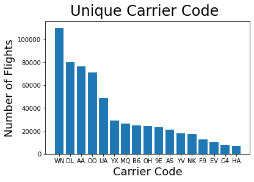

```python
uniqueCarrierCode = flights_df.OP_UNIQUE_CARRIER.value_counts()
plt.suptitle('Unique Carrier Code', fontsize=24)
plt.xlabel('Carrier Code', fontsize=18)
plt.ylabel('Number of Flights', fontsize=18)
plt.bar(uniqueCarrierCode.index, uniqueCarrierCode);
```

#### How many primary airports?

```python
flights_df['ORIGIN_AIRPORT_ID'].nunique()
```

```
351
```

There are 351 primary airports.

#### Number of Airlines?

```python
flights_df['OP_UNIQUE_CARRIER'].nunique()
```

```
17
```

There are 17 Airlines.

#### Which airport has the most departing flights? least departing flights?

[figure not shown]

```python
depstate = flights_df.ORIGIN.value_counts()
plt.figure(figsize=[180,8])
plt.suptitle('Departing flights per Airport', fontsize=24)
plt.xlabel('Airport Code', fontsize=18)
plt.ylabel('Number of Flights', fontsize=18)
plt.bar(depstate.index, depstate);
```

Hartsfield Jackson Atlanta International Airport (IATA Code ATL) has the most departing flights out of all airports in the US.

Yellowstone Regional Airport (IATA Code COD) has the least amount of departing flights int he US.

#### What Percentage of all flights depart from or arrive at Atlanta International Airport?

```python
atlFlightsD = len(flights_df.query('DEST == "ATL"'))
atlFlightsO = len(flights_df.query('ORIGIN == "ATL"'))
allATLFlights = atlFlightsD + atlFlightsO
```

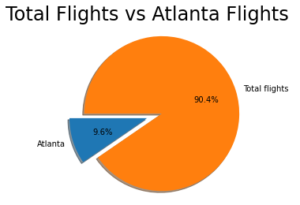

```python
labels = 'Atlanta', 'Total flights'
sizes = [allATLFlights, totalNumberOfFlights]
explode = (0.2, 0)

fig1, pieat = plt.subplots()
pieat.pie(sizes, explode=explode, labels=labels, autopct='%1.1f%%',
        shadow=True, startangle=180)
pieat.axis('equal')
plt.suptitle('Total Flights vs Atlanta Flights ', fontsize=24)
plt.show()
```

#### Number of Flights diverted?

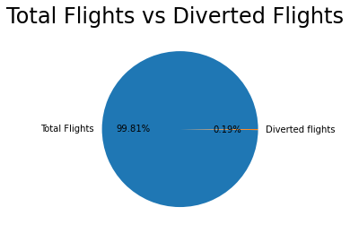

```python
labels = 'Total Flights', 'Diverted flights'
plt.suptitle('Total Flights vs Diverted Flights', fontsize=24)
plt.pie(flights_df.DIVERTED.value_counts(),labels=labels, autopct='%.2f%%');
```

0.19% of all flights were diverted

#### Relationship between states based on Arrival and Departure.

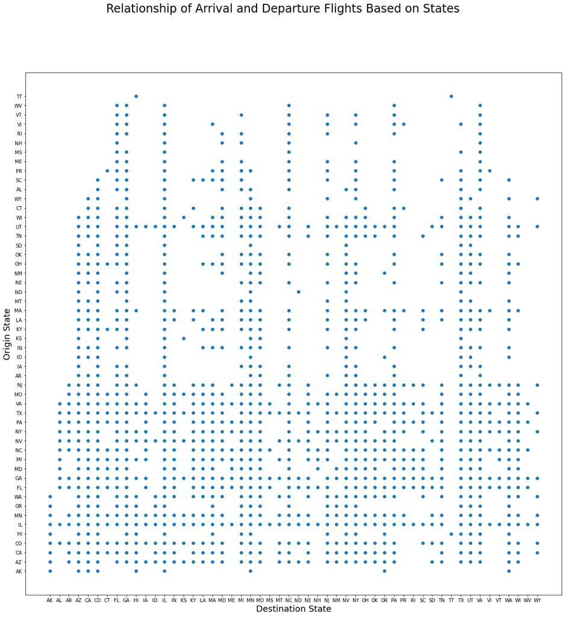

```python
state_airlines = flights_df.groupby(['ORIGIN_STATE_ABR', 'DEST_STATE_ABR'], as_index=False).count()
state_airlines = state_airlines[['ORIGIN_STATE_ABR', 'DEST_STATE_ABR']]
plt.figure(figsize=[20,20])
plt.suptitle('Relationship of Arrival and Departure Flights Based on States ', fontsize=24)
plt.xlabel('Destination State', fontsize=18)
plt.ylabel('Origin State', fontsize=18)
plt.scatter(state_airlines.ORIGIN_STATE_ABR, state_airlines.DEST_STATE_ABR);
```

Using scatter plot we can see the relationships of all states based on flight paths. The state of Illinois(IL) has had flights departing to all states and arriving form all states except for Trust Territory(TT).

#### Relationship between states based on Arrival and Departure with travel time.

```python
airTimeMean = flights_df.AIR_TIME.mean()
```

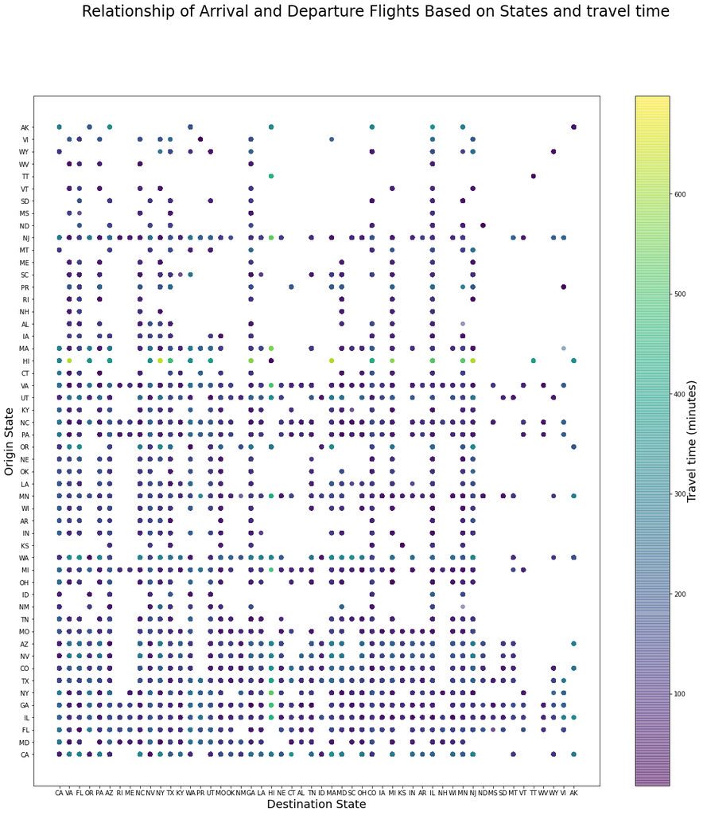

```python
def airTimeColor(x):
    aT_max, aT_min = airTimeMean, -(airTimeMean)
    if(x>aT_max):
        x=aT_max
    elif(x<aT_min):
        x=aT_min
    return x
flights_df.DepDelay = flights_df.AIR_TIME.apply(airTimeColor)
plt.figure(figsize=[20,20])
plt.suptitle('Relationship of Arrival and Departure Flights Based on States and travel time', fontsize=24)
plt.xlabel('Destination State', fontsize=18)
plt.ylabel('Origin State', fontsize=18)
plt.scatter(x=flights_df.ORIGIN_STATE_ABR, y=flights_df.DEST_STATE_ABR, alpha=.5, c=flights_df.AIR_TIME)
colorBar = plt.colorbar();
colorBar.set_label("Travel time (minutes)",fontsize=18, labelpad=+2)
plt.show()
```

ref: https://matplotlib.org/3.1.1/gallery/pie_and_polar_charts/pie_features.html#sphx-glr-gallery-pie-and-polar-charts-pie-features-py